# Retail_Fraud_Detection

Ali Jazzar

2026-05-20

# Introduction

The objective of this project is to explore whether fraudulent transactions can be effectively identified using transaction and customer-related variables, and to compare different predictive modeling approaches for fraud detection.

This project focuses on two main business questions:

1. Can fraudulent transactions be identified using available predictor variables?
2. Which predictive model performs best at detecting fraudulent transactions while minimizing classification errors?

By answering these questions, the project aims to evaluate the effectiveness of statistical and machine learning approaches for fraud detection and identify the model that provides the strongest predictive performance.

# Data

This project uses the `retail_fraud_detection_100k.csv` dataset obtained from Kaggle:

https://www.kaggle.com/datasets/noopurbhatt/retail-intelligence-fraud-detection-dataset

The dataset contains transaction-level information that can be used to analyze fraud patterns and develop predictive models for fraud detection.

# Methodology

The project follows the steps below:

1. Data Import
2. Exploratory Data Analysis
3. Data Cleaning & Preprocessing
4. Feature Engineering
5. Train/Test Split
6. Predictive Modeling
7. Model Evaluation & Comparison

# Tools

This project was developed entirely using R and RStudio.

# Libraries

The following R libraries were used throughout the project:

- tidyverse
- caret
- glmnet
- ranger
- pROC
- corrplot
- ROSE
- vip
- yardstick
- lubridate
- rpart
- rpart.plot

## Libraries installation

```r
library(tidyverse)
library(caret)
library(glmnet)
library(ranger)
library(pROC)
```

```r
library(corrplot)
library(ROSE)
library(vip)
library(yardstick)
library(lubridate)
library(rpart)
library(rpart.plot)
```

## Import Data

```r
df <- read_csv("retail_fraud_detection_100k.csv")
head(df)
```

```
## # A tibble: 6 × 21
##   transaction_id customer_id transaction_timestamp transaction_amount
##   <chr>          <chr>       <dttm>                             <dbl>
## 1 T0000001       C20953      2026-03-04 19:56:23                 56.3
## 2 T0000002       C24133      2026-03-09 19:56:23                 20.4
## 3 T0000003       C07165      2026-01-01 19:56:23                 48.7
## 4 T0000004       C19310      2025-12-09 19:56:23                154.
## 5 T0000005       C25019      2025-11-09 19:56:23                115.
## 6 T0000006       C08668      2026-04-08 19:56:23                 41.3
## # ℹ 17 more variables: payment_method <chr>, device_type <chr>, location <chr>,
## #   merchant_category <chr>, is_international <dbl>,
## #   transaction_frequency_24h <dbl>, avg_transaction_amount_7d <dbl>,
## #   failed_transaction_count_24h <dbl>, account_age_days <dbl>,
## #   previous_fraud_flag <dbl>, unusual_amount_flag <dbl>,
## #   unusual_location_flag <dbl>, multiple_transactions_short_time <dbl>,
## #   high_risk_device_flag <dbl>, velocity_flag <dbl>, fraud_flag <dbl>, …
```

The dataset contains 100,000 observations and 21 variables related to customer transactions, payment behavior, device usage, and fraud indicators.

## Dataset Structure

```r
glimpse(df)
```

```
## Rows: 100,000
## Columns: 21
## $ transaction_id                   <chr> "T0000001", "T0000002", "T0000003", "…
## $ customer_id                      <chr> "C20953", "C24133", "C07165", "C19310…
## $ transaction_timestamp            <dttm> 2026-03-04 19:56:23, 2026-03-09 19:5…
## $ transaction_amount               <dbl> 56.31, 20.35, 48.72, 153.62, 115.32, …
## $ payment_method                   <chr> "Debit Card", "Credit Card", "Debit C…
## $ device_type                      <chr> "Tablet", "Tablet", "Tablet", "Mobile…
## $ location                         <chr> "Canada", "India", "UK", "Australia",…
## $ merchant_category                <chr> "Fashion", "Electronics", "Travel", "…
## $ is_international                 <dbl> 0, 0, 0, 0, 0, 1, 1, 0, 0, 0, 0, 1, 0…
## $ transaction_frequency_24h        <dbl> 13, 3, 8, 14, 10, 11, 14, 9, 7, 10, 1…
## $ avg_transaction_amount_7d        <dbl> 53.02, 38.00, 147.45, 58.22, 114.46, …
## $ failed_transaction_count_24h     <dbl> 4, 2, 4, 3, 3, 3, 2, 2, 0, 4, 4, 1, 1…
## $ account_age_days                 <dbl> 1054, 97, 779, 286, 866, 709, 1909, 6…
## $ previous_fraud_flag              <dbl> 0, 0, 1, 1, 0, 1, 0, 1, 0, 1, 1, 1, 1…
## $ unusual_amount_flag              <dbl> 0, 0, 0, 1, 0, 0, 0, 1, 0, 0, 1, 0, 0…
## $ unusual_location_flag            <dbl> 0, 0, 0, 0, 0, 1, 1, 0, 0, 0, 0, 1, 0…
## $ multiple_transactions_short_time <dbl> 1, 0, 0, 1, 1, 1, 1, 1, 0, 1, 1, 1, 1…
## $ high_risk_device_flag            <dbl> 0, 0, 0, 0, 0, 0, 0, 0, 0, 0, 0, 0, 0…
## $ velocity_flag                    <dbl> 1, 0, 0, 1, 0, 1, 1, 0, 0, 0, 1, 1, 1…
## $ fraud_flag                       <dbl> 0, 0, 0, 1, 0, 1, 1, 1, 0, 1, 1, 1, 1…
## $ fraud_risk                       <chr> "Medium", "Low", "Medium", "High", "L…
```

```r
colSums(is.na(df))
```

```
##                   transaction_id                      customer_id
##                                0                                0
##            transaction_timestamp               transaction_amount
##                                0                                0
##                   payment_method                      device_type
##                                0                                0
##                         location                merchant_category
##                                0                                0
##                 is_international        transaction_frequency_24h
##                                0                                0
##        avg_transaction_amount_7d     failed_transaction_count_24h
##                                0                                0
##                 account_age_days              previous_fraud_flag
##                                0                                0
##              unusual_amount_flag            unusual_location_flag
##                                0                                0
## multiple_transactions_short_time            high_risk_device_flag
##                                0                                0
##                    velocity_flag                       fraud_flag
##                                0                                0
##                       fraud_risk
##                                0
```

```r
str(df)
```

```
## spc_tbl_ [100,000 × 21] (S3: spec_tbl_df/tbl_df/tbl/data.frame)
##  $ transaction_id                  : chr [1:100000] "T0000001" "T0000002" "T0000003" "T0000004" ...
##  $ customer_id                     : chr [1:100000] "C20953" "C24133" "C07165" "C19310" ...
##  $ transaction_timestamp           : POSIXct[1:100000], format: "2026-03-04 19:56:23" "2026-03-09 19:56:23" ...
##  $ transaction_amount              : num [1:100000] 56.3 20.4 48.7 153.6 115.3 ...
##  $ payment_method                  : chr [1:100000] "Debit Card" "Credit Card" "Debit Card" "Debit Card" ...
##  $ device_type                     : chr [1:100000] "Tablet" "Tablet" "Tablet" "Mobile" ...
##  $ location                        : chr [1:100000] "Canada" "India" "UK" "Australia" ...
##  $ merchant_category               : chr [1:100000] "Fashion" "Electronics" "Travel" "Fashion" ...
##  $ is_international                : num [1:100000] 0 0 0 0 0 1 1 0 0 0 ...
##  $ transaction_frequency_24h       : num [1:100000] 13 3 8 14 10 11 14 9 7 10 ...
##  $ avg_transaction_amount_7d       : num [1:100000] 53 38 147.4 58.2 114.5 ...
##  $ failed_transaction_count_24h    : num [1:100000] 4 2 4 3 3 3 2 2 0 4 ...
##  $ account_age_days                : num [1:100000] 1054 97 779 286 866 ...
##  $ previous_fraud_flag             : num [1:100000] 0 0 1 1 0 1 0 1 0 1 ...
##  $ unusual_amount_flag             : num [1:100000] 0 0 0 1 0 0 0 1 0 0 ...
##  $ unusual_location_flag           : num [1:100000] 0 0 0 0 0 1 1 0 0 0 ...
##  $ multiple_transactions_short_time: num [1:100000] 1 0 0 1 1 1 1 1 0 1 ...
##  $ high_risk_device_flag           : num [1:100000] 0 0 0 0 0 0 0 0 0 0 ...
##  $ velocity_flag                   : num [1:100000] 1 0 0 1 0 1 1 0 0 0 ...
##  $ fraud_flag                      : num [1:100000] 0 0 0 1 0 1 1 1 0 1 ...
##  $ fraud_risk                      : chr [1:100000] "Medium" "Low" "Medium" "High" ...
##  - attr(*, "spec")=
##   .. cols(
##   ..   transaction_id = col_character(),
##   ..   customer_id = col_character(),
##   ..   transaction_timestamp = col_datetime(format = ""),
##   ..   transaction_amount = col_double(),
##   ..   payment_method = col_character(),
##   ..   device_type = col_character(),
##   ..   location = col_character(),
##   ..   merchant_category = col_character(),
##   ..   is_international = col_double(),
##   ..   transaction_frequency_24h = col_double(),
##   ..   avg_transaction_amount_7d = col_double(),
##   ..   failed_transaction_count_24h = col_double(),
##   ..   account_age_days = col_double(),
##   ..   previous_fraud_flag = col_double(),
##   ..   unusual_amount_flag = col_double(),
##   ..   unusual_location_flag = col_double(),
##   ..   multiple_transactions_short_time = col_double(),
##   ..   high_risk_device_flag = col_double(),
##   ..   velocity_flag = col_double(),
##   ..   fraud_flag = col_double(),
##   ..   fraud_risk = col_character()
##   .. )
##  - attr(*, "problems")=<pointer: 0x000001b67fdff280>
```

The dataset structure was inspected to better understand variable types, identify missing values, and validate the overall data format before preprocessing and modeling.

## Feature Preparation

The following preprocessing steps were performed to prepare the dataset for statistical and machine learning models:

- Converted categorical variables into factor variables
- Extracted transaction hour information
- Extracted day-of-week information from transaction timestamps

```r
df1 <- df

# Convert categorical variables to factor variables
# for proper handling in statistical and machine learning models.

df1$payment_method <- factor(df1$payment_method)
df1$device_type <- factor(df1$device_type)
df1$location <- factor(df1$location)
df1$merchant_category <- factor(df1$merchant_category)

df1$is_international <- factor(df1$is_international)
df1$previous_fraud_flag <- factor(df1$previous_fraud_flag)
df1$unusual_amount_flag <- factor(df1$unusual_amount_flag)
df1$unusual_location_flag <- factor(df1$unusual_location_flag)

df1$multiple_transactions_short_time <- factor(df1$multiple_transactions_short_time)
df1$high_risk_device_flag <- factor(df1$high_risk_device_flag)
df1$velocity_flag <- factor(df1$velocity_flag)

df1$fraud_flag <- factor(df1$fraud_flag)
df1$fraud_risk <- factor(df1$fraud_risk)

# Extract transaction hour and transaction day information.

df1$transaction_hour <- hour(df1$transaction_timestamp)

df1$transaction_day <- factor(
  wday(df1$transaction_timestamp, label = TRUE)
)
```

## Exploratory Data Analysis (EDA)

Initial exploratory analysis was performed to better understand the dataset structure, variable distributions, and potential relationships between fraud-related indicators.

```r
summary(df1)
```

```
##    transaction_id      customer_id     transaction_timestamp
##  Length   :100000   Length   :100000   Min.   :2025-04-30 19:56:23
##  N.unique :100000   N.unique : 28955   1st Qu.:2025-07-30 19:56:25
##  N.blank  :     0   N.blank  :     0   Median :2025-10-29 19:56:24
##  Min.nchar:     8   Min.nchar:     6   Mean   :2025-10-30 00:32:57
##  Max.nchar:     8   Max.nchar:     6   3rd Qu.:2026-01-28 19:56:25
##                                        Max.   :2026-04-30 19:56:25
##
##  transaction_amount     payment_method   device_type         location
##  Min.   :   0.00    Apple Pay  :20098   Desktop:33284   Australia:16710
##  1st Qu.:  34.82    Credit Card:19942   Mobile :33454   Canada   :16708
##  Median :  84.13    Debit Card :19960   Tablet :33262   Germany  :16759
##  Mean   : 120.48    Google Pay :19951                   India    :16604
##  3rd Qu.: 167.52    PayPal     :20049                   UK       :16523
##  Max.   :1548.52                                        USA      :16696
##
##    merchant_category is_international transaction_frequency_24h
##  Electronics:16543   0:50199          Min.   : 1.00
##  Fashion    :16893   1:49801          1st Qu.: 4.00
##  Gaming     :16720                    Median : 7.00
##  Groceries  :16699                    Mean   : 7.49
##  Luxury     :16755                    3rd Qu.:11.00
##  Travel     :16390                    Max.   :14.00
##
##  avg_transaction_amount_7d failed_transaction_count_24h account_age_days
##  Min.   : 20.00            Min.   :0.000                Min.   :  10
##  1st Qu.: 64.91            1st Qu.:1.000                1st Qu.: 510
##  Median :109.78            Median :2.000                Median :1004
##  Mean   :109.81            Mean   :2.004                Mean   :1005
##  3rd Qu.:154.67            3rd Qu.:3.000                3rd Qu.:1501
##  Max.   :200.00            Max.   :4.000                Max.   :1999
##
##  previous_fraud_flag unusual_amount_flag unusual_location_flag
##  0:49985             0:77047             0:50199
##  1:50015             1:22953             1:49801
##
##
##
##
##
##  multiple_transactions_short_time high_risk_device_flag velocity_flag
##  0:57296                          0:89904               0:71602
##  1:42704                          1:10096               1:28398
##
##
##
##
##
##  fraud_flag  fraud_risk    transaction_hour transaction_day
##  0:52492    High  :15586   Min.   :19       Sun:14325
##  1:47508    Low   :32203   1st Qu.:19       Mon:14053
##             Medium:52211   Median :19       Tue:14286
##                            Mean   :19       Wed:14591
##                            3rd Qu.:19       Thu:14444
##                            Max.   :19       Fri:14200
##                                             Sat:14101
```

```r
# Provides an overview of the dataset structure,
# variable types, and summary statistics.

table(df1$is_international, df1$unusual_location_flag)
```

```
##
##         0     1
##   0 50199     0
##   1     0 49801
```

```r
# Remove redundant variable due to identical information content.

df1 <- df1 %>%
  select(-unusual_location_flag)
```

```r
df2 <- df1

# Create a weekend/weekday feature from the transaction day.
# This simplifies the day-of-week variable while keeping useful temporal information.

df2$week_period <- factor(case_when(
  df2$transaction_day %in% c("Sat", "Sun") ~ "Weekend",
  TRUE ~ "Weekday"
))

# Remove timestamp-related variables after extracting useful time-based features.
# The transaction timestamp itself is not directly used in the models.
# Additionally, all transaction hours were equal to 19 (7 PM), meaning the transaction_hour variable contained no useful variability for predictive modeling.

df2 <- df2 %>%
  select(-transaction_timestamp, -transaction_hour, -transaction_day)


# Remove fraud_risk because it appears to be a pre-engineered fraud indicator.
# Keeping this variable could introduce leakage and lead to unrealistic model performance.

df2 <- df2 %>%
  select(-fraud_risk)


# Remove ID variables because they do not provide generalizable predictive information and may increase model complexity without adding analytical value.

df2 <- df2 %>%
  select(-transaction_id, -customer_id)
```

The objective was to extract useful information from the `transaction_timestamp` variable while avoiding the direct use of raw timestamp values in the models.

```r
summary(df2$week_period)
```

```
## Weekday Weekend
##   71574   28426
```

```r
# Explore the distribution of transactions between weekdays and weekends.
```

```r
# Explore the proportional distribution of fraudulent and non-fraudulent transactions across categorical predictor variables.

prop.table(table(df2$payment_method, df2$fraud_flag), 1)
```

```
##
##                       0         1
##   Apple Pay   0.5275152 0.4724848
##   Credit Card 0.5227159 0.4772841
##   Debit Card  0.5245491 0.4754509
##   Google Pay  0.5236329 0.4763671
##   PayPal      0.5261609 0.4738391
```

```r
prop.table(table(df2$device_type, df2$fraud_flag), 1)
```

```
##
##                   0         1
##   Desktop 0.5508352 0.4491648
##   Mobile  0.4806899 0.5193101
##   Tablet  0.5434730 0.4565270
```

```r
prop.table(table(df2$location, df2$fraud_flag), 1)
```

```
##
##                     0         1
##   Australia 0.5208857 0.4791143
##   Canada    0.5262748 0.4737252
##   Germany   0.5203174 0.4796826
##   India     0.5251747 0.4748253
##   UK        0.5279913 0.4720087
##   USA       0.5289291 0.4710709
```

```r
prop.table(table(df2$merchant_category, df2$fraud_flag), 1)
```

```
##
##                       0         1
##   Electronics 0.5300731 0.4699269
##   Fashion     0.5202155 0.4797845
##   Gaming      0.5252392 0.4747608
##   Groceries   0.5260794 0.4739206
##   Luxury      0.5227693 0.4772307
##   Travel      0.5252593 0.4747407
```

```r
prop.table(table(df2$previous_fraud_flag, df2$fraud_flag), 1)
```

```
##
##            0        1
##   0 0.736501 0.263499
##   1 0.313466 0.686534
```

```r
prop.table(table(df2$unusual_amount_flag, df2$fraud_flag), 1)
```

```
##
##             0         1
##   0 0.6147027 0.3852973
##   1 0.2235438 0.7764562
```

```r
prop.table(table(df2$is_international, df2$fraud_flag), 1)
```

```
##
##             0         1
##   0 0.7352736 0.2647264
##   1 0.3128853 0.6871147
```

```r
prop.table(table(df2$multiple_transactions_short_time, df2$fraud_flag), 1)
```

```
##
##             0         1
##   0 0.6751082 0.3248918
##   1 0.3234123 0.6765877
```

```r
prop.table(table(df2$high_risk_device_flag, df2$fraud_flag), 1)
```

```
##
##             0         1
##   0 0.5460714 0.4539286
##   1 0.3365689 0.6634311
```

```r
prop.table(table(df2$velocity_flag, df2$fraud_flag), 1)
```

```
##
##             0         1
##   0 0.6275383 0.3724617
##   1 0.2661807 0.7338193
```

```r
prop.table(table(df2$week_period, df2$fraud_flag), 1)
```

```
##
##                   0         1
##   Weekday 0.5271467 0.4728533
##   Weekend 0.5193133 0.4806867
```

Several variables appear strongly associated with fraudulent transactions, particularly:

- International transactions
- Previous fraud history
- Unusual transaction amounts
- High transaction velocity
- Multiple transactions within a short period

These findings suggest that behavioral transaction patterns may play an important role in predictive fraud modeling.

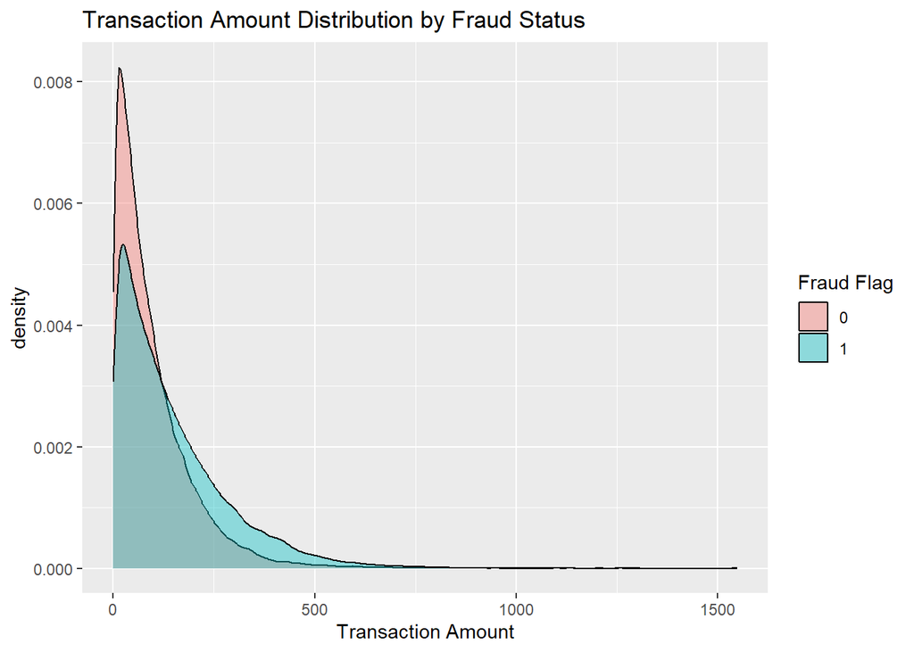

```r
# Explore the distribution of numerical variables by fraud status to identify potential behavioral differences between fraudulent and non-fraudulent transactions.


ggplot(df2, aes(x = transaction_amount, fill = factor(fraud_flag))) +
  geom_density(alpha = 0.4) +
  labs(
    title = "Transaction Amount Distribution by Fraud Status",
    x = "Transaction Amount",
    fill = "Fraud Flag"
  )
```

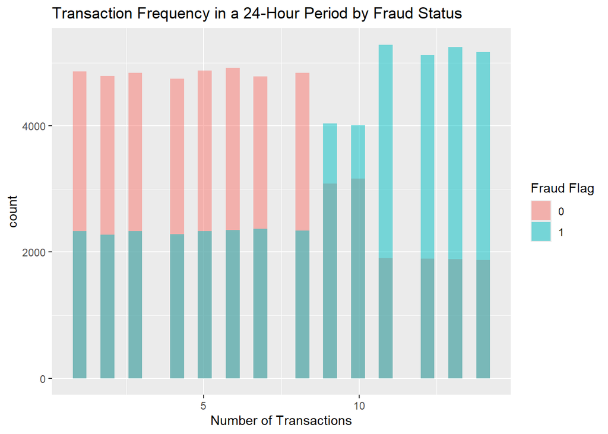

```r
ggplot(df2, aes(x = transaction_frequency_24h, fill = factor(fraud_flag))) +
  geom_histogram(position = "identity", alpha = 0.5, bins = 30) +
  labs(
    title = "Transaction Frequency in a 24-Hour Period by Fraud Status",
    x = "Number of Transactions",
    fill = "Fraud Flag"
  )
```

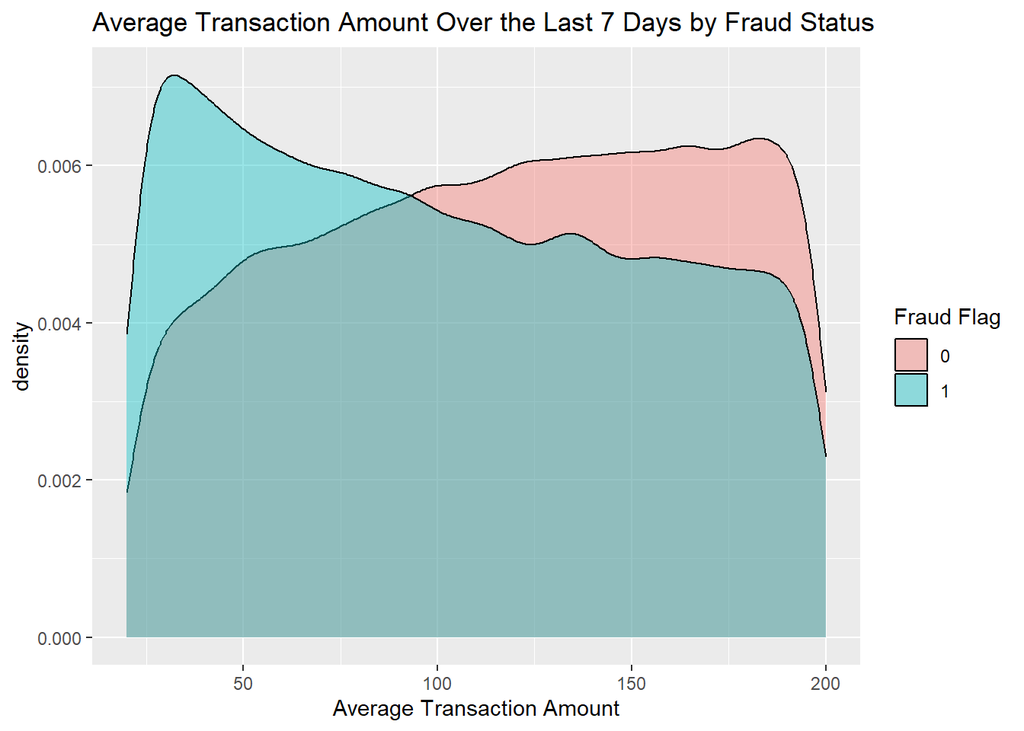

```r
ggplot(df2, aes(x = avg_transaction_amount_7d, fill = factor(fraud_flag))) +
  geom_density(alpha = 0.4) +
  labs(
    title = "Average Transaction Amount Over the Last 7 Days by Fraud Status",
    x = "Average Transaction Amount",
    fill = "Fraud Flag"
  )
```

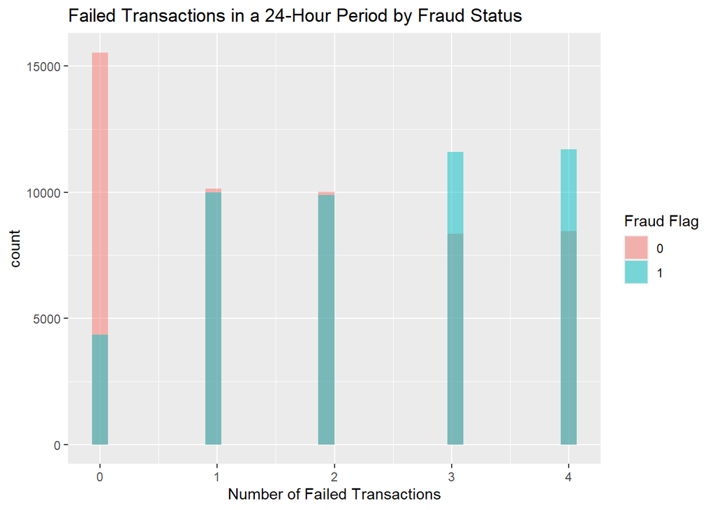

```r
ggplot(df2, aes(x = failed_transaction_count_24h, fill = factor(fraud_flag))) +
  geom_histogram(position = "identity", alpha = 0.5, bins = 30) +
  labs(
    title = "Failed Transactions in a 24-Hour Period by Fraud Status",
    x = "Number of Failed Transactions",
    fill = "Fraud Flag"
  )
```

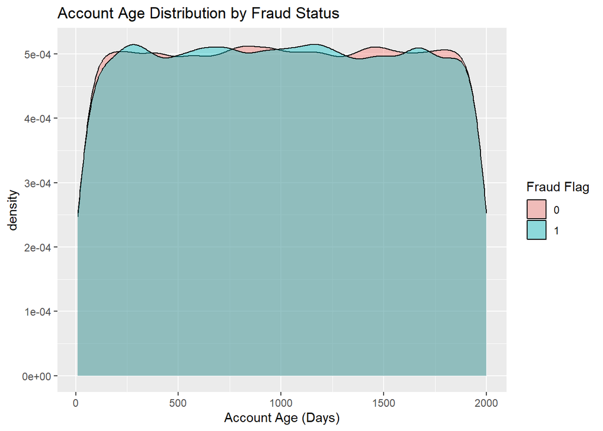

```r
ggplot(df2, aes(x = account_age_days, fill = factor(fraud_flag))) +
  geom_density(alpha = 0.4) +
  labs(
    title = "Account Age Distribution by Fraud Status",
    x = "Account Age (Days)",
    fill = "Fraud Flag"
  )
```

The number of transactions within a 24-hour period appeared to be strongly associated with fraudulent behavior. Fraudulent transactions became increasingly dominant at higher transaction frequencies, suggesting that transaction velocity may be an important indicator of fraud risk.

```r
# Select numerical variables for correlation analysis.

numeric_df <- df2 %>%
  select(where(is.numeric))


# Compute the correlation matrix between numerical variables.

cor(numeric_df)
```

```
##                              transaction_amount transaction_frequency_24h
## transaction_amount                 1.0000000000             -3.042289e-04
## transaction_frequency_24h         -0.0003042289              1.000000e+00
## avg_transaction_amount_7d         -0.0001192943             -4.540214e-05
## failed_transaction_count_24h      -0.0041610062             -2.448489e-04
## account_age_days                   0.0033162174             -4.849502e-03
##                              avg_transaction_amount_7d
## transaction_amount                       -1.192943e-04
## transaction_frequency_24h                -4.540214e-05
## avg_transaction_amount_7d                 1.000000e+00
## failed_transaction_count_24h             -1.181298e-02
## account_age_days                          2.059045e-03
##                              failed_transaction_count_24h account_age_days
## transaction_amount                          -0.0041610062      0.003316217
## transaction_frequency_24h                   -0.0002448489     -0.004849502
## avg_transaction_amount_7d                   -0.0118129756      0.002059045
## failed_transaction_count_24h                 1.0000000000     -0.002920367
## account_age_days                            -0.0029203666      1.000000000
```

The Correlation analysis between numerical variables revealed very weak linear relationships across features. This suggests that multicollinearity is unlikely to be a major issue for the logistic regression model and that numerical variables may provide complementary predictive information.

# Train/Test Split

```r
# Split the dataset into training and testing datasets using stratified sampling to preserve the fraud class distribution.

set.seed(123)

train_index <- createDataPartition(
  df2$fraud_flag,
  p = 0.8,
  list = FALSE
)

train_data <- df2[train_index, ]

test_data <- df2[-train_index, ]


# Display the number of observations in each dataset.

dim(train_data)
```

```
## [1] 80001    17
```

```r
dim(test_data)
```

```
## [1] 19999    17
```

```r
# Verify that the fraud class distribution remains consistent across the training and testing datasets.

prop.table(table(train_data$fraud_flag))
```

```
##
##         0         1
## 0.5249184 0.4750816
```

```r
prop.table(table(test_data$fraud_flag))
```

```
##
##         0         1
## 0.5249262 0.4750738
```

The class distribution remained consistent between the training and testing datasets, confirming that the stratified sampling approach successfully preserved the original fraud class proportions.

# test GLM

```r
# GLM Baseline Model


glm_test <- glm(
  fraud_flag ~ .,
  data = train_data,
  family = "binomial"
)
summary(glm_test)
```

```
##
## Call:
## glm(formula = fraud_flag ~ ., family = "binomial", data = train_data)
##
## Coefficients:
##                                     Estimate Std. Error z value Pr(>|z|)
## (Intercept)                       -3.696e+02  4.691e+03  -0.079    0.937
## transaction_amount                -1.761e-04  3.076e+00   0.000    1.000
## payment_methodCredit Card          5.769e-03  8.151e+02   0.000    1.000
## payment_methodDebit Card          -1.405e-02  8.264e+02   0.000    1.000
## payment_methodGoogle Pay          -1.176e-02  8.237e+02   0.000    1.000
## payment_methodPayPal              -3.149e-02  8.199e+02   0.000    1.000
## device_typeMobile                 -3.871e-02  7.054e+02   0.000    1.000
## device_typeTablet                 -6.582e-03  6.345e+02   0.000    1.000
## locationCanada                    -3.669e-02  9.000e+02   0.000    1.000
## locationGermany                   -2.053e-02  9.021e+02   0.000    1.000
## locationIndia                     -1.750e-02  9.013e+02   0.000    1.000
## locationUK                        -1.893e-03  9.127e+02   0.000    1.000
## locationUSA                       -3.224e-02  9.058e+02   0.000    1.000
## merchant_categoryFashion           9.995e-02  9.106e+02   0.000    1.000
## merchant_categoryGaming            5.857e-02  9.082e+02   0.000    1.000
## merchant_categoryGroceries         1.215e-01  9.029e+02   0.000    1.000
## merchant_categoryLuxury            1.229e-01  9.007e+02   0.000    1.000
## merchant_categoryTravel            9.144e-02  9.134e+02   0.000    1.000
## is_international1                  1.739e+02  2.127e+03   0.082    0.935
## transaction_frequency_24h          9.566e-04  1.453e+02   0.000    1.000
## avg_transaction_amount_7d          2.808e-05  5.955e+00   0.000    1.000
## failed_transaction_count_24h       4.323e+01  5.491e+02   0.079    0.937
## account_age_days                   9.050e-06  4.515e-01   0.000    1.000
## previous_fraud_flag1               1.739e+02  2.126e+03   0.082    0.935
## unusual_amount_flag1               1.739e+02  2.279e+03   0.076    0.939
## multiple_transactions_short_time1  8.743e+01  1.496e+03   0.058    0.953
## high_risk_device_flag1             8.732e+01  1.467e+03   0.060    0.953
## velocity_flag1                     8.641e+01  1.387e+03   0.062    0.950
## week_periodWeekend                 9.188e-03  5.762e+02   0.000    1.000
##
## (Dispersion parameter for binomial family taken to be 1)
##
##     Null deviance: 1.1071e+05  on 80000  degrees of freedom
## Residual deviance: 1.0846e-05  on 79972  degrees of freedom
## AIC: 58
##
## Number of Fisher Scoring iterations: 25
```

Some fraud-related variables appeared to provide near-perfect predictive power, resulting in signs of quasi-perfect separation within the GLM model. To improve model interpretability and simulate a more realistic fraud detection environment, an alternative reduced model excluding highly deterministic fraud-related variables was also explored.

```r
train_data <- train_data %>%
  select(
    -previous_fraud_flag,
    -unusual_amount_flag,
    -high_risk_device_flag,
    -velocity_flag
  )

test_data <- test_data %>%
  select(
    -previous_fraud_flag,
    -unusual_amount_flag,
    -high_risk_device_flag,
    -velocity_flag
  )


# Remove highly deterministic fraud-related variables that may have been generated using pre-existing fraud models or business rules. Excluding these variables helps create a more realistic fraud detection scenario and reduces the risk of feature leakage.
```

```r
glm_test2 <- glm(
  fraud_flag ~ .,
  data = train_data,
  family = "binomial"
)

summary(glm_test2)
```

```
##
## Call:
## glm(formula = fraud_flag ~ ., family = "binomial", data = train_data)
##
## Coefficients:
##                                     Estimate Std. Error z value Pr(>|z|)
## (Intercept)                       -4.056e+00  5.984e-02 -67.775   <2e-16 ***
## transaction_amount                 6.620e-03  9.316e-05  71.064   <2e-16 ***
## payment_methodCredit Card          4.517e-02  3.009e-02   1.501   0.1333
## payment_methodDebit Card          -9.827e-03  3.005e-02  -0.327   0.7436
## payment_methodGoogle Pay          -1.144e-02  3.006e-02  -0.381   0.7035
## payment_methodPayPal               1.298e-02  3.003e-02   0.432   0.6656
## device_typeMobile                  4.921e-01  2.344e-02  20.993   <2e-16 ***
## device_typeTablet                  5.737e-02  2.337e-02   2.455   0.0141 *
## locationCanada                    -2.563e-02  3.294e-02  -0.778   0.4364
## locationGermany                   -1.848e-02  3.302e-02  -0.560   0.5757
## locationIndia                     -5.931e-02  3.302e-02  -1.796   0.0725 .
## locationUK                        -2.238e-02  3.310e-02  -0.676   0.4989
## locationUSA                       -5.575e-02  3.302e-02  -1.688   0.0914 .
## merchant_categoryFashion           3.989e-02  3.288e-02   1.213   0.2251
## merchant_categoryGaming            3.663e-02  3.300e-02   1.110   0.2671
## merchant_categoryGroceries         3.743e-02  3.292e-02   1.137   0.2555
## merchant_categoryLuxury            5.508e-02  3.300e-02   1.669   0.0951 .
## merchant_categoryTravel            2.311e-02  3.317e-02   0.697   0.4860
## is_international1                  2.747e+00  2.256e-02 121.782   <2e-16 ***
## transaction_frequency_24h          8.995e-02  4.647e-03  19.354   <2e-16 ***
## avg_transaction_amount_7d         -9.425e-03  1.898e-04 -49.650   <2e-16 ***
## failed_transaction_count_24h       5.752e-01  7.321e-03  78.563   <2e-16 ***
## account_age_days                   4.558e-06  1.664e-05   0.274   0.7841
## multiple_transactions_short_time1  1.737e+00  3.805e-02  45.646   <2e-16 ***
## week_periodWeekend                 2.721e-02  2.108e-02   1.291   0.1968
## ---
## Signif. codes:  0 '***' 0.001 '**' 0.01 '*' 0.05 '.' 0.1 ' ' 1
##
## (Dispersion parameter for binomial family taken to be 1)
##
##     Null deviance: 110706  on 80000  degrees of freedom
## Residual deviance:  68197  on 79976  degrees of freedom
## AIC: 68247
##
## Number of Fisher Scoring iterations: 5
```

The reduced model appears to provide a more realistic and interpretable representation of fraud behavior patterns.

# GLM Model

```r
# The GLM is used as an interpretable baseline model.
# Since the target variable is binary, we use logistic regression with a binomial family.

glm_full <- glm(
  fraud_flag ~ .,
  data = train_data,
  family = "binomial"
)

summary(glm_full)
```

```
##
## Call:
## glm(formula = fraud_flag ~ ., family = "binomial", data = train_data)
##
## Coefficients:
##                                     Estimate Std. Error z value Pr(>|z|)
## (Intercept)                       -4.056e+00  5.984e-02 -67.775   <2e-16 ***
## transaction_amount                 6.620e-03  9.316e-05  71.064   <2e-16 ***
## payment_methodCredit Card          4.517e-02  3.009e-02   1.501   0.1333
## payment_methodDebit Card          -9.827e-03  3.005e-02  -0.327   0.7436
## payment_methodGoogle Pay          -1.144e-02  3.006e-02  -0.381   0.7035
## payment_methodPayPal               1.298e-02  3.003e-02   0.432   0.6656
## device_typeMobile                  4.921e-01  2.344e-02  20.993   <2e-16 ***
## device_typeTablet                  5.737e-02  2.337e-02   2.455   0.0141 *
## locationCanada                    -2.563e-02  3.294e-02  -0.778   0.4364
## locationGermany                   -1.848e-02  3.302e-02  -0.560   0.5757
## locationIndia                     -5.931e-02  3.302e-02  -1.796   0.0725 .
## locationUK                        -2.238e-02  3.310e-02  -0.676   0.4989
## locationUSA                       -5.575e-02  3.302e-02  -1.688   0.0914 .
## merchant_categoryFashion           3.989e-02  3.288e-02   1.213   0.2251
## merchant_categoryGaming            3.663e-02  3.300e-02   1.110   0.2671
## merchant_categoryGroceries         3.743e-02  3.292e-02   1.137   0.2555
## merchant_categoryLuxury            5.508e-02  3.300e-02   1.669   0.0951 .
## merchant_categoryTravel            2.311e-02  3.317e-02   0.697   0.4860
## is_international1                  2.747e+00  2.256e-02 121.782   <2e-16 ***
## transaction_frequency_24h          8.995e-02  4.647e-03  19.354   <2e-16 ***
## avg_transaction_amount_7d         -9.425e-03  1.898e-04 -49.650   <2e-16 ***
## failed_transaction_count_24h       5.752e-01  7.321e-03  78.563   <2e-16 ***
## account_age_days                   4.558e-06  1.664e-05   0.274   0.7841
## multiple_transactions_short_time1  1.737e+00  3.805e-02  45.646   <2e-16 ***
## week_periodWeekend                 2.721e-02  2.108e-02   1.291   0.1968
## ---
## Signif. codes:  0 '***' 0.001 '**' 0.01 '*' 0.05 '.' 0.1 ' ' 1
##
## (Dispersion parameter for binomial family taken to be 1)
##
##     Null deviance: 110706  on 80000  degrees of freedom
## Residual deviance:  68197  on 79976  degrees of freedom
## AIC: 68247
##
## Number of Fisher Scoring iterations: 5
```

```r
# Full GLM - Predictions on Test Data

glm_prob <- predict(
  glm_full,
  newdata = test_data,
  type = "response"
)


# Full GLM - ROC Curve and Optimal Cutoff

glm_roc <- roc(
  response = as.numeric(as.character(test_data$fraud_flag)),
  predictor = glm_prob
)
optimal_cutoff <- coords(
  glm_roc,
  x = "best",
  best.method = "youden",
  ret = "threshold",
  transpose = FALSE
)

optimal_cutoff <- as.numeric(optimal_cutoff$threshold)

optimal_cutoff
```

```
## [1] 0.4621966
```

```r
# Full GLM - Predicted Classes Using Optimal Cutoff

glm_pred_optimal <- ifelse(
  glm_prob >= optimal_cutoff,
  1,
  0
)


# Full GLM - Confusion Matrix

confusionMatrix(
  factor(glm_pred_optimal, levels = c(0, 1)),
  factor(test_data$fraud_flag, levels = c(0, 1)),
  positive = "1"
)
```

```
## Confusion Matrix and Statistics
##
##           Reference
## Prediction    0    1
##          0 8146 1928
##          1 2352 7573
##
##                Accuracy : 0.786
##                  95% CI : (0.7802, 0.7917)
##     No Information Rate : 0.5249
##     P-Value [Acc > NIR] : < 2.2e-16
##
##                   Kappa : 0.5718
##
##  Mcnemar's Test P-Value : 1.008e-10
##
##             Sensitivity : 0.7971
##             Specificity : 0.7760
##          Pos Pred Value : 0.7630
##          Neg Pred Value : 0.8086
##              Prevalence : 0.4751
##          Detection Rate : 0.3787
##    Detection Prevalence : 0.4963
##       Balanced Accuracy : 0.7865
##
##        'Positive' Class : 1
##
```

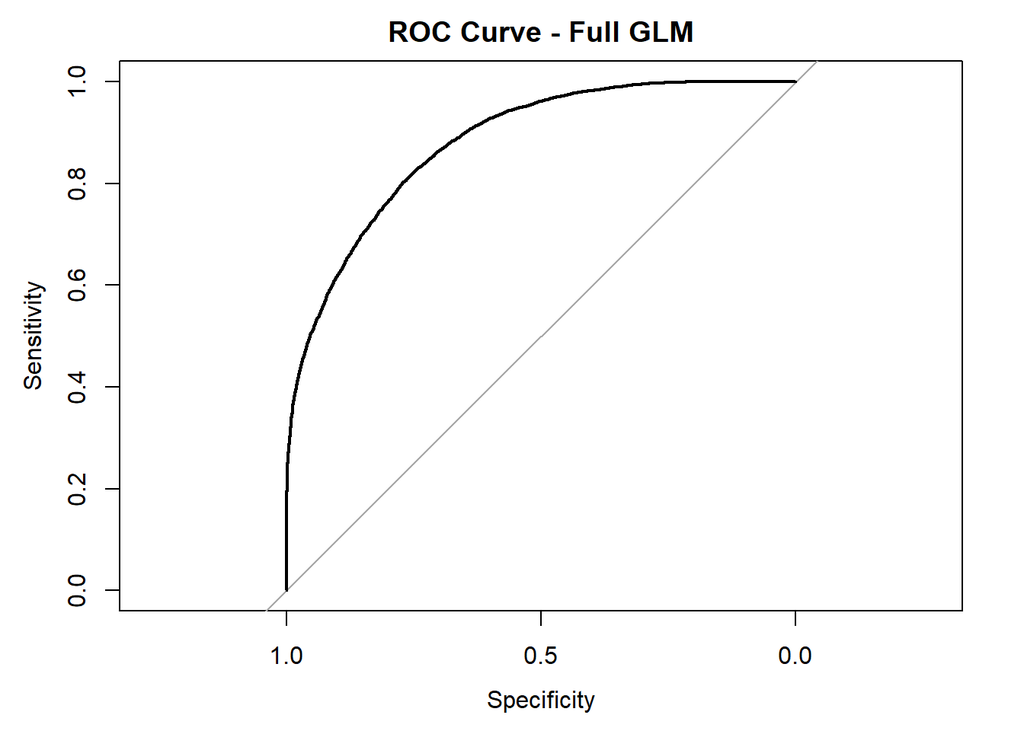

```r
# Full GLM - ROC Curve and AUC

plot(glm_roc, main = "ROC Curve - Full GLM")
```

```r
glm_auc <- auc(glm_roc)

glm_auc
```

```
## Area under the curve: 0.8805
```

```r
# Variable Selection Using drop1()

# drop1() tests the contribution of each original variable, to the model, rather than testing each dummy variable separately.
# This is useful when categorical variables are included in the model.

drop_results <- drop1(
  glm_full,
  test = "Chisq"
)

drop_results
```

```
## Single term deletions
##
## Model:
## fraud_flag ~ transaction_amount + payment_method + device_type +
##     location + merchant_category + is_international + transaction_frequency_24h +
##     avg_transaction_amount_7d + failed_transaction_count_24h +
##     account_age_days + multiple_transactions_short_time + week_period
##                                  Df Deviance   AIC     LRT Pr(>Chi)
## <none>                                 68197 68247
## transaction_amount                1    74353 74401  6155.7   <2e-16 ***
## payment_method                    4    68202 68244     4.7   0.3143
## device_type                       2    68730 68776   532.5   <2e-16 ***
## location                          5    68202 68242     4.8   0.4371
## merchant_category                 5    68201 68241     3.2   0.6674
## is_international                  1    88815 88863 20617.8   <2e-16 ***
## transaction_frequency_24h         1    68575 68623   377.7   <2e-16 ***
## avg_transaction_amount_7d         1    70801 70849  2604.0   <2e-16 ***
## failed_transaction_count_24h      1    75302 75350  7104.2   <2e-16 ***
## account_age_days                  1    68198 68246     0.1   0.7841
## multiple_transactions_short_time  1    70390 70438  2193.0   <2e-16 ***
## week_period                       1    68199 68247     1.7   0.1968
## ---
## Signif. codes:  0 '***' 0.001 '**' 0.01 '*' 0.05 '.' 0.1 ' ' 1
```

```r
# Extract variables with p-value below 5%.
# We remove NA values and the special "<none>" row before creating the formula.

drop_results_df <- as.data.frame(drop_results)

significant_vars <- rownames(drop_results_df)[
  !is.na(drop_results_df$`Pr(>Chi)`) &
    drop_results_df$`Pr(>Chi)` < 0.05
]

significant_vars <- setdiff(significant_vars, "<none>")

significant_vars
```

```
## [1] "transaction_amount"               "device_type"
## [3] "is_international"                 "transaction_frequency_24h"
## [5] "avg_transaction_amount_7d"        "failed_transaction_count_24h"
## [7] "multiple_transactions_short_time"
```

```r
# Build the partial GLM formula using only statistically significant variables.

partial_formula <- reformulate(
  significant_vars,
  response = "fraud_flag"
)

partial_formula
```

```
## fraud_flag ~ transaction_amount + device_type + is_international +
##     transaction_frequency_24h + avg_transaction_amount_7d + failed_transaction_count_24h +
##     multiple_transactions_short_time
```

```r
# Train the partial GLM model using only significant variables.

glm_partial <- glm(
  partial_formula,
  data = train_data,
  family = "binomial"
)

summary(glm_partial)
```

```
##
## Call:
## glm(formula = partial_formula, family = "binomial", data = train_data)
##
## Coefficients:
##                                     Estimate Std. Error z value Pr(>|z|)
## (Intercept)                       -4.033e+00  4.507e-02 -89.496   <2e-16 ***
## transaction_amount                 6.619e-03  9.314e-05  71.070   <2e-16 ***
## device_typeMobile                  4.918e-01  2.344e-02  20.985   <2e-16 ***
## device_typeTablet                  5.712e-02  2.336e-02   2.445   0.0145 *
## is_international1                  2.746e+00  2.255e-02 121.784   <2e-16 ***
## transaction_frequency_24h          8.991e-02  4.646e-03  19.353   <2e-16 ***
## avg_transaction_amount_7d         -9.419e-03  1.897e-04 -49.640   <2e-16 ***
## failed_transaction_count_24h       5.751e-01  7.319e-03  78.570   <2e-16 ***
## multiple_transactions_short_time1  1.737e+00  3.804e-02  45.658   <2e-16 ***
## ---
## Signif. codes:  0 '***' 0.001 '**' 0.01 '*' 0.05 '.' 0.1 ' ' 1
##
## (Dispersion parameter for binomial family taken to be 1)
##
##     Null deviance: 110706  on 80000  degrees of freedom
## Residual deviance:  68212  on 79992  degrees of freedom
## AIC: 68230
##
## Number of Fisher Scoring iterations: 5
```

```r
# Partial GLM - Predictions on Test Data


partial_prob <- predict(
  glm_partial,
  newdata = test_data,
  type = "response"
)



# Partial GLM - ROC Curve and Optimal Cutoff


partial_roc <- roc(
  response = as.numeric(as.character(test_data$fraud_flag)),
  predictor = partial_prob
)
partial_cutoff <- coords(
  partial_roc,
  x = "best",
  best.method = "youden",
  ret = "threshold",
  transpose = FALSE
)

partial_cutoff <- as.numeric(partial_cutoff$threshold)

partial_cutoff
```

```
## [1] 0.4519027
```

```r
# Partial GLM - Predicted Classes Using Optimal Cutoff


partial_pred_optimal <- ifelse(
  partial_prob >= partial_cutoff,
  1,
  0
)


# Partial GLM - Confusion Matrix

confusionMatrix(
  factor(partial_pred_optimal, levels = c(0, 1)),
  factor(test_data$fraud_flag, levels = c(0, 1)),
  positive = "1"
)
```

```
## Confusion Matrix and Statistics
##
##           Reference
## Prediction    0    1
##          0 8076 1855
##          1 2422 7646
##
##                Accuracy : 0.7861
##                  95% CI : (0.7804, 0.7918)
##     No Information Rate : 0.5249
##     P-Value [Acc > NIR] : < 2.2e-16
##
##                   Kappa : 0.5724
##
##  Mcnemar's Test P-Value : < 2.2e-16
##
##             Sensitivity : 0.8048
##             Specificity : 0.7693
##          Pos Pred Value : 0.7594
##          Neg Pred Value : 0.8132
##              Prevalence : 0.4751
##          Detection Rate : 0.3823
##    Detection Prevalence : 0.5034
##       Balanced Accuracy : 0.7870
##
##        'Positive' Class : 1
##
```

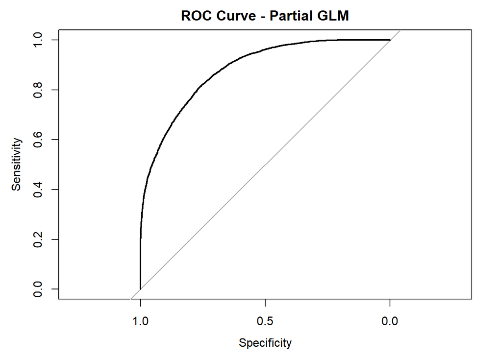

```r
# Partial GLM - ROC Curve and AUC


plot(partial_roc, main = "ROC Curve - Partial GLM")
```

```r
partial_auc <- auc(partial_roc)

partial_auc
```

```
## Area under the curve: 0.8806
```

The full GLM model was first used as an interpretable baseline. A reduced partial GLM model was then created using `drop1()` to identify statistically significant variables at the 5% level. This approach keeps categorical variables at the original variable level rather than selecting individual dummy variables, making the reduced model more interpretable and statistically coherent.

```r
#  Ridge / Lasso Logistic Regression


# Create model matrices
x_train <- model.matrix(fraud_flag ~ ., train_data)[, -1]
y_train <- train_data$fraud_flag

x_test <- model.matrix(fraud_flag ~ ., test_data)[, -1]
y_test <- test_data$fraud_flag

# Ridge: alpha = 0
set.seed(123)

ridge_model <- cv.glmnet(
  x_train,
  y_train,
  family = "binomial",
  alpha = 0,
  type.measure = "auc"
)

ridge_prob <- predict(
  ridge_model,
  newx = x_test,
  s = "lambda.min",
  type = "response"
)

ridge_roc <- roc(
  response = as.numeric(as.character(y_test)),
  predictor = as.numeric(ridge_prob)
)
ridge_cutoff <- coords(
  ridge_roc,
  x = "best",
  best.method = "youden",
  ret = "threshold",
  transpose = FALSE
)

ridge_cutoff <- as.numeric(ridge_cutoff$threshold)

ridge_pred_optimal <- ifelse(
  as.numeric(ridge_prob) >= ridge_cutoff,
  1,
  0
)

confusionMatrix(
  factor(ridge_pred_optimal, levels = c(0, 1)),
  factor(y_test, levels = c(0, 1)),
  positive = "1"
)
```

```
## Confusion Matrix and Statistics
##
##           Reference
## Prediction    0    1
##          0 8032 1817
##          1 2466 7684
##
##                Accuracy : 0.7858
##                  95% CI : (0.7801, 0.7915)
##     No Information Rate : 0.5249
##     P-Value [Acc > NIR] : < 2.2e-16
##
##                   Kappa : 0.572
##
##  Mcnemar's Test P-Value : < 2.2e-16
##
##             Sensitivity : 0.8088
##             Specificity : 0.7651
##          Pos Pred Value : 0.7570
##          Neg Pred Value : 0.8155
##              Prevalence : 0.4751
##          Detection Rate : 0.3842
##    Detection Prevalence : 0.5075
##       Balanced Accuracy : 0.7869
##
##        'Positive' Class : 1
##
```

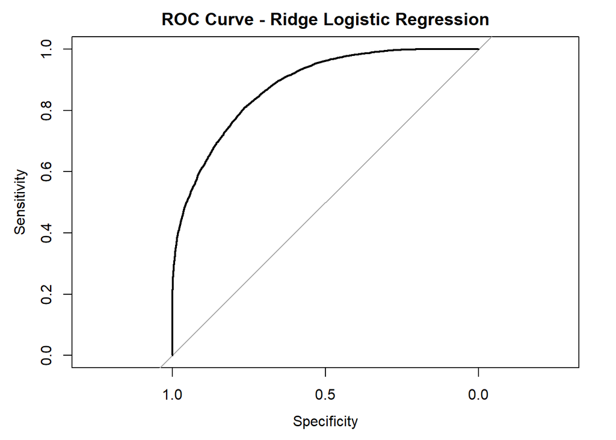

```r
plot(ridge_roc, main = "ROC Curve - Ridge Logistic Regression")
```

```r
ridge_auc <- auc(ridge_roc)
ridge_auc
```

```
## Area under the curve: 0.8799
```

```r
# Lasso: alpha = 1
set.seed(123)

lasso_model <- cv.glmnet(
  x_train,
  y_train,
  family = "binomial",
  alpha = 1,
  type.measure = "auc"
)

lasso_prob <- predict(
  lasso_model,
  newx = x_test,
  s = "lambda.min",
  type = "response"
)

lasso_roc <- roc(
  response = as.numeric(as.character(y_test)),
  predictor = as.numeric(lasso_prob)
)
lasso_cutoff <- coords(
  lasso_roc,
  x = "best",
  best.method = "youden",
  ret = "threshold",
  transpose = FALSE
)

lasso_cutoff <- as.numeric(lasso_cutoff$threshold)

lasso_pred_optimal <- ifelse(
  as.numeric(lasso_prob) >= lasso_cutoff,
  1,
  0
)

confusionMatrix(
  factor(lasso_pred_optimal, levels = c(0, 1)),
  factor(y_test, levels = c(0, 1)),
  positive = "1"
)
```

```
## Confusion Matrix and Statistics
##
##           Reference
## Prediction    0    1
##          0 8041 1825
##          1 2457 7676
##
##                Accuracy : 0.7859
##                  95% CI : (0.7801, 0.7916)
##     No Information Rate : 0.5249
##     P-Value [Acc > NIR] : < 2.2e-16
##
##                   Kappa : 0.5721
##
##  Mcnemar's Test P-Value : < 2.2e-16
##
##             Sensitivity : 0.8079
##             Specificity : 0.7660
##          Pos Pred Value : 0.7575
##          Neg Pred Value : 0.8150
##              Prevalence : 0.4751
##          Detection Rate : 0.3838
##    Detection Prevalence : 0.5067
##       Balanced Accuracy : 0.7869
##
##        'Positive' Class : 1
##
```

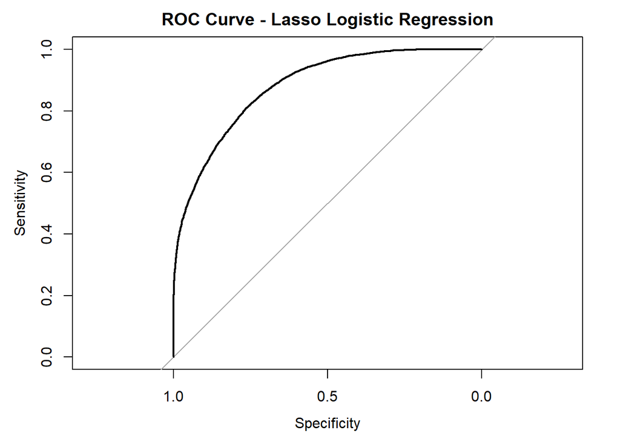

```r
plot(lasso_roc, main = "ROC Curve - Lasso Logistic Regression")
```

```r
lasso_auc <- auc(lasso_roc)
lasso_auc
```

```
## Area under the curve: 0.8806
```

```r
# Decision Tree Model

# A decision tree is used to capture nonlinear relationships, between variables while remaining highly interpretable.


set.seed(123)

tree_model <- rpart(
  fraud_flag ~ .,
  data = train_data,
  method = "class"
)

summary(tree_model)
```

```
## Call:
## rpart(formula = fraud_flag ~ ., data = train_data, method = "class")
##   n= 80001
##
##           CP nsplit rel error    xerror        xstd
## 1 0.39284869      0 1.0000000 1.0000000 0.003716329
## 2 0.03984792      1 0.6071513 0.6071513 0.003371479
## 3 0.01783882      3 0.5274555 0.5274555 0.003224946
## 4 0.01589181      5 0.4917778 0.4917778 0.003148985
## 5 0.01000000      7 0.4599942 0.4602310 0.003075953
##
## Variable importance
##                 is_international        transaction_frequency_24h
##                               41                               29
## multiple_transactions_short_time     failed_transaction_count_24h
##                               14                               14
##               transaction_amount
##                                2
##
## Node number 1: 80001 observations,    complexity param=0.3928487
##   predicted class=0  expected loss=0.4750816  P(node) =1
##     class counts: 41994 38007
##    probabilities: 0.525 0.475
##   left son=2 (40182 obs) right son=3 (39819 obs)
##   Primary splits:
##       is_international                 splits as  LR,          improve=7153.373, (0 missing)
##       transaction_frequency_24h        < 8.5     to the left,  improve=4895.293, (0 missing)
##       multiple_transactions_short_time splits as  LR,          improve=4895.293, (0 missing)
##       failed_transaction_count_24h     < 0.5     to the left,  improve=2633.439, (0 missing)
##       transaction_amount               < 145.77  to the left,  improve=1375.291, (0 missing)
##   Surrogate splits:
##       transaction_frequency_24h        < 8.5     to the left,  agree=0.506, adj=0.008, (0 split)
##       multiple_transactions_short_time splits as  LR,          agree=0.506, adj=0.008, (0 split)
##       location                         splits as  LLLRLL,      agree=0.504, adj=0.004, (0 split)
##       avg_transaction_amount_7d        < 37.775  to the right, agree=0.504, adj=0.003, (0 split)
##       transaction_amount               < 91.695  to the right, agree=0.503, adj=0.002, (0 split)
##
## Node number 2: 40182 observations,    complexity param=0.01783882
##   predicted class=0  expected loss=0.2645961  P(node) =0.5022687
##     class counts: 29550 10632
```

[output cut: 104 more lines]

```
##
## Node number 23: 4075 observations
##   predicted class=1  expected loss=0.2650307  P(node) =0.05093686
##     class counts:  1080  2995
##    probabilities: 0.265 0.735
##
## Node number 44: 3138 observations
##   predicted class=0  expected loss=0.3075207  P(node) =0.03922451
##     class counts:  2173   965
##    probabilities: 0.692 0.308
##
## Node number 45: 6329 observations
##   predicted class=1  expected loss=0.4487281  P(node) =0.07911151
##     class counts:  2840  3489
##    probabilities: 0.449 0.551
```

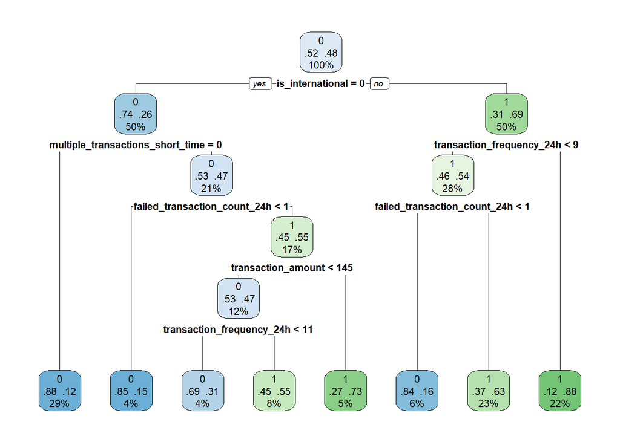

```r
# Decision Tree Visualization

# Visualize the tree structure and decision rules.

rpart.plot(
  tree_model,
  type = 2,
  extra = 104,
  fallen.leaves = TRUE
)
```

```r
# Decision Tree - Predictions on Test Data


tree_prob <- predict(
  tree_model,
  newdata = test_data,
  type = "prob"
)[,2]

tree_pred <- ifelse(tree_prob >= 0.5, 1, 0)


# Decision Tree - Confusion Matrix


confusionMatrix(
  factor(tree_pred),
  factor(test_data$fraud_flag),
  positive = "1"
)
```

```
## Confusion Matrix and Statistics
##
##           Reference
## Prediction    0    1
##          0 7316 1198
##          1 3182 8303
##
##                Accuracy : 0.781
##                  95% CI : (0.7752, 0.7867)
##     No Information Rate : 0.5249
##     P-Value [Acc > NIR] : < 2.2e-16
##
##                   Kappa : 0.5652
##
##  Mcnemar's Test P-Value : < 2.2e-16
##
##             Sensitivity : 0.8739
##             Specificity : 0.6969
##          Pos Pred Value : 0.7229
##          Neg Pred Value : 0.8593
##              Prevalence : 0.4751
##          Detection Rate : 0.4152
##    Detection Prevalence : 0.5743
##       Balanced Accuracy : 0.7854
##
##        'Positive' Class : 1
##
```

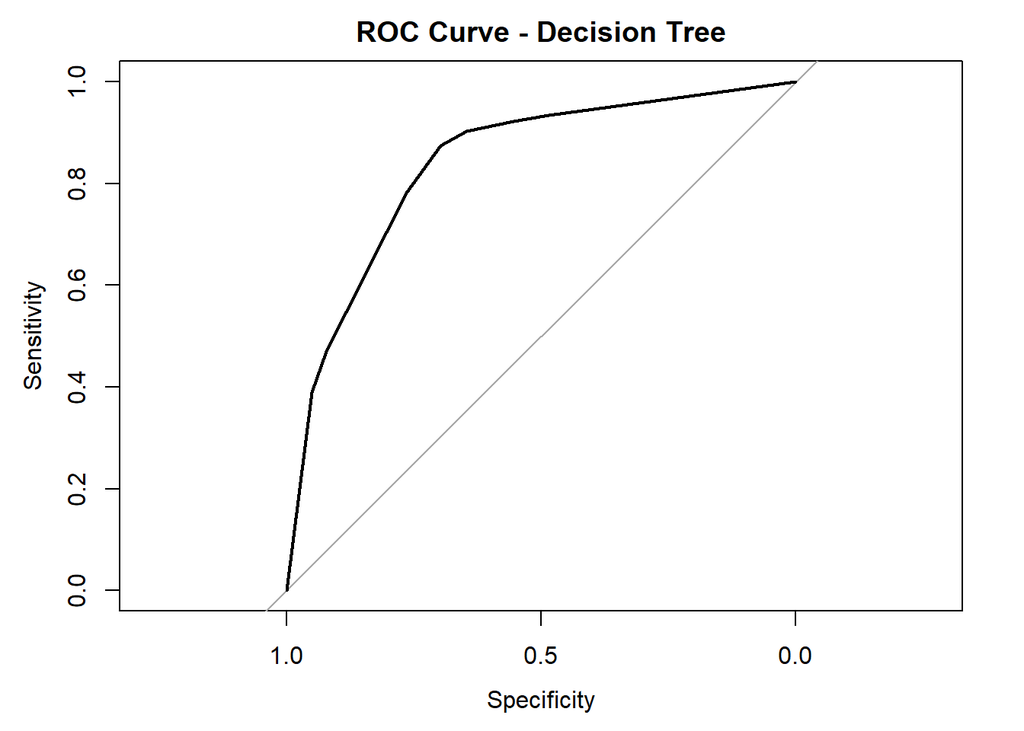

```r
# Decision Tree - ROC Curve and AUC


tree_roc <- roc(
  test_data$fraud_flag,
  tree_prob
)
plot(tree_roc, main = "ROC Curve - Decision Tree")
```

```r
tree_auc <- auc(tree_roc)

tree_auc
```

```
## Area under the curve: 0.8386
```

The Decision Tree structure highlights the importance of behavioral transaction variables in fraud classification decisions.

Variables such as international transactions, transaction frequency, failed transaction attempts, and multiple transactions within short periods appeared near the top of the tree, indicating that they played a major role in the model’s decision-making process.

The tree visualization also demonstrates how nonlinear decision rules and variable interactions can naturally emerge in fraud detection models.

The Decision Tree model was included as a more interpretable nonlinear modeling approach. Unlike logistic regression, decision trees can naturally capture interaction effects and nonlinear relationships between predictors.

However, single decision trees are generally less stable and less accurate than ensemble methods such as Random Forest models.

```r
#  Random Forest


set.seed(123)

rf_model <- ranger(
  fraud_flag ~ .,
  data = train_data,
  probability = TRUE,
  importance = "impurity",
  num.trees = 500
)
rf_prob <- predict(rf_model, data = test_data)$predictions[, "1"]
rf_pred <- ifelse(rf_prob >= 0.5, 1, 0)

confusionMatrix(
  factor(rf_pred),
  factor(test_data$fraud_flag),
  positive = "1"
)
```

```
## Confusion Matrix and Statistics
##
##           Reference
## Prediction    0    1
##          0 8062 1773
##          1 2436 7728
##
##                Accuracy : 0.7895
##                  95% CI : (0.7838, 0.7952)
##     No Information Rate : 0.5249
##     P-Value [Acc > NIR] : < 2.2e-16
##
##                   Kappa : 0.5794
##
##  Mcnemar's Test P-Value : < 2.2e-16
##
##             Sensitivity : 0.8134
##             Specificity : 0.7680
##          Pos Pred Value : 0.7603
##          Neg Pred Value : 0.8197
##              Prevalence : 0.4751
##          Detection Rate : 0.3864
##    Detection Prevalence : 0.5082
##       Balanced Accuracy : 0.7907
##
##        'Positive' Class : 1
##
```

```r
rf_roc <- roc(test_data$fraud_flag, rf_prob)
```

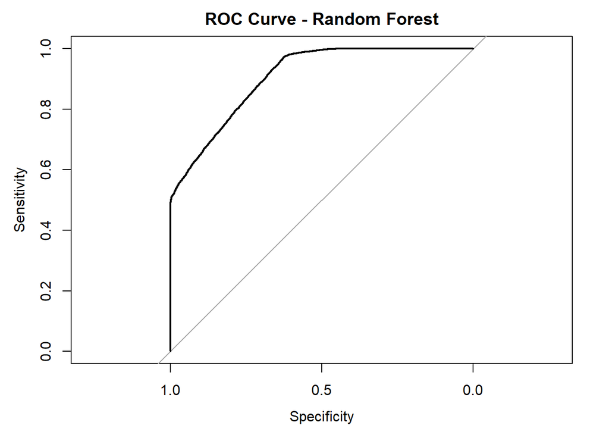

```r
plot(rf_roc, main = "ROC Curve - Random Forest")
```

```r
auc(rf_roc)
```

```
## Area under the curve: 0.906
```

The Random Forest model achieved the strongest predictive performance among all evaluated models, with the highest AUC score and improved classification accuracy compared to the linear models.

This result suggests that fraud behavior may involve complex nonlinear relationships and interaction effects that are not fully captured by traditional logistic regression models.

In addition to improved predictive performance, Random Forest models are generally more robust to multicollinearity and better suited for capturing complex behavioral fraud patterns across multiple variables simultaneously.

However, Random Forest models are typically less interpretable than logistic regression models, making it more difficult to directly quantify the impact of individual variables on fraud probability.

```r
#  Feature Importance - Random Forest


importance_df <- data.frame(
  Variable = names(rf_model$variable.importance),
  Importance = rf_model$variable.importance
)

importance_df <- importance_df %>%
  arrange(desc(Importance))

importance_df
```

```
##                                                          Variable Importance
## is_international                                 is_international  7214.9116
## transaction_amount                             transaction_amount  5093.4620
## transaction_frequency_24h               transaction_frequency_24h  3974.6867
## failed_transaction_count_24h         failed_transaction_count_24h  3943.9541
## avg_transaction_amount_7d               avg_transaction_amount_7d  3830.9195
## multiple_transactions_short_time multiple_transactions_short_time  2484.7565
## account_age_days                                 account_age_days  2413.4756
## location                                                 location   888.5521
## merchant_category                               merchant_category   888.1451
## payment_method                                     payment_method   768.9556
## device_type                                           device_type   479.0512
## week_period                                           week_period   264.8456
```

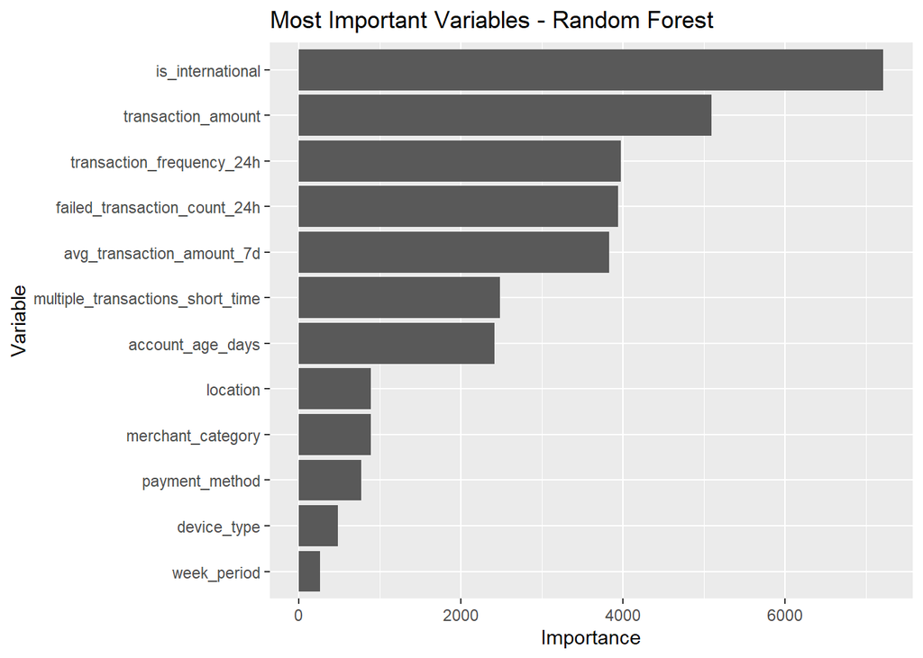

```r
ggplot(importance_df[1:12, ], aes(x = reorder(Variable, Importance), y = Importance)) +
  geom_col() +
  coord_flip() +
  labs(
    title = "Most Important Variables - Random Forest",
    x = "Variable",
    y = "Importance"
  )
```

The Random Forest variable importance analysis suggests that behavioral transaction variables contributed most strongly to fraud prediction performance.

International transactions appeared to be the most influential predictor, followed by transaction amount, transaction frequency, failed transaction attempts, and average transaction behavior over the previous 7 days.

These findings reinforce the idea that fraud detection is primarily driven by abnormal behavioral patterns rather than static customer characteristics.

The relatively lower importance of variables such as payment method, device type, and weekday/weekend activity suggests that these variables may contribute less predictive information compared to transaction behavior indicators.

Interestingly, many of the variables identified as highly important by the Random Forest model were also retained in the reduced Partial GLM model through the statistical variable selection process using `drop1()`. This consistency across multiple modeling approaches strengthens the reliability of the findings and suggests that these behavioral variables contain meaningful predictive information for fraud detection.

```r
#  Model Comparison Table

model_results <- data.frame(
  Model = c(
    "GLM Full",
    "GLM Partial",
    "Ridge",
    "Lasso",
    "Decision Tree",
    "Random Forest"
  ),
  AUC = c(
    glm_auc,
    partial_auc,
    auc(ridge_roc),
    auc(lasso_roc),
    tree_auc,
    auc(rf_roc)
  )
)

model_results
```

```
##           Model       AUC
## 1      GLM Full 0.8805300
## 2   GLM Partial 0.8805534
## 3         Ridge 0.8798914
## 4         Lasso 0.8805574
## 5 Decision Tree 0.8385791
## 6 Random Forest 0.9060348
```

The Random Forest model achieved the highest AUC score, suggesting that it provided the strongest overall discriminatory power between fraudulent and non-fraudulent transactions.

This result suggests that nonlinear relationships and interactions between predictors may be important in fraud detection. However, the GLM remains valuable because it provides stronger interpretability through coefficients and odds ratios.